# 04 Post-Estratificacion

LMT

marzo de 2022

### Post-Estratificación

¿Para qué sirve?. Veamos un ejemplo particular antes de abordar la forma general.

Si intentamos hacer una muestra de 100 para una población de 1,000 y sólo obtenemos respuesta de 76, la fracción de muestreo no es 100/1,000 sino 76/1,000. La corrección al factor de expansión es lo que la post-estratificacion hace.

**pregunta** ¿Qué puede ocasionar datos faltantes en su información?.

**Dos puntos a consderar**. Necesitamos calibrar nuestros factores de expansión para que ajusten con el total poblacional y además nos ayuda a conocer el porcentaje de no respuesta por lo que si habíamos considerado que requeriamos una población de tamaño n para cumplir con intervalos con cierto nivel de confianza y un margen de error fijado, requeriremos mayor muestra. ¿cuánta muestra más?. Si revisamos la nota metodológica de encuestas como el Censo o ENIGH veremos que el tamaño de muestra lo ajustan utilizando la siguiente expresión.

$\text{n ajustada} = \frac{n \cdot deff}{1 - tnr}$

donde $tnr$ es la tasa de no respuesta

De momento nosotros sólo utilizaremos la tasa de no respuesta. Por lo que nuestro tamaño de muestra para futuros estudios queda de la siguiente manera.

$\text{n ajustada} = \frac{n}{1 - tnr}$

Para el ejemplo utilizaemos los datos de personas de aguascalientes del censo de 2010. Consideraremos los datos como nuestro universo (Población) y la variable de municipo como la variable de estrato.

```r
# Limpiar área de trabajo
rm(list = ls())
```

```r
# Cargar librerías
suppressMessages(library(tidyverse))
library(ggplot2)
library(readr)

suppressMessages(library(survey))

library(haven) # Permite leer tablas en formato guardado por SAS
```

Leer datos

```r
personas_01 <- read_sas("/home/leonardo/Documentos/Acatlan/Datos/Censo_2010/MC2010_01_sas/personas_01_a.sas7bdat", NULL) %>%
  # Conservar sólo ciertas variables
  select(ENT,NOM_ENT, MUN, NOM_MUN, ID_VIV, ID_PER, NUMPER, SEXO, EDAD, PARENT, IDMADRE, NIVACAD, ESCOACUM, ALFABET,NUMHIJ) %>%
  # Convertir la edad a númerica
  mutate(edad_numerica = parse_number(EDAD))

glimpse(personas_01)
```

```
## Rows: 69,804
## Columns: 16
## $ ENT           <chr> "01", "01", "01", "01", "01", "01", "01", "01", "01", "0…
## $ NOM_ENT       <chr> "Aguascalientes", "Aguascalientes", "Aguascalientes", "A…
## $ MUN           <chr> "001", "001", "001", "001", "001", "001", "001", "001", …
## $ NOM_MUN       <chr> "Aguascalientes", "Aguascalientes", "Aguascalientes", "A…
## $ ID_VIV        <chr> "00068033", "00068033", "00068033", "00068039", "0006803…
## $ ID_PER        <chr> "000284687", "000284692", "000284695", "000284701", "000…
## $ NUMPER        <chr> "00001", "00002", "00003", "00001", "00002", "00001", "0…
## $ SEXO          <chr> "1", "3", "3", "3", "1", "1", "3", "1", "3", "1", "3", "…
## $ EDAD          <chr> "064", "046", "020", "084", "047", "057", "043", "019", …
## $ PARENT        <chr> "01", "02", "03", "01", "03", "01", "02", "03", "03", "0…
## $ IDMADRE       <chr> "", "", "02", "", "01", "", "", "02", "02", "02", "02", …
## $ NIVACAD       <chr> "02", "02", "08", "02", "02", "03", "03", "04", "04", "0…
## $ ESCOACUM      <chr> "06", "06", "13", "03", "06", "09", "09", "12", "11", "0…
## $ ALFABET       <chr> "1", "1", "1", "1", "1", "1", "1", "1", "1", "1", "1", "…
## $ NUMHIJ        <chr> "", "03", "00", "15", "", "", "05", "", "00", "", "00", …
## $ edad_numerica <dbl> 64, 46, 20, 84, 47, 57, 43, 19, 17, 15, 14, 10, 48, 45, …
```

¿Cuántas personas hay y cuál es la edad promedio?

```r
personas_01 %>% summarise(num_personas = n_distinct(ID_PER), promedio_edad = mean(edad_numerica), sd_edad = sd(edad_numerica), min_edad = min(edad_numerica), max_edad = max(edad_numerica))
```

```
## # A tibble: 1 x 5
##   num_personas promedio_edad sd_edad min_edad max_edad
##          <int>         <dbl>   <dbl>    <dbl>    <dbl>
## 1        69804          27.4    28.1        0      999
```

¿Cuál es el número de elementos (personas) por estrato?

```r
personas_01 %>% group_by(ENT,MUN) %>%
  summarise(num_personas = n_distinct(ID_PER), promedio_edad = mean(edad_numerica), sd_edad = sd(edad_numerica))
```

```
## # A tibble: 11 x 5
## # Groups:   ENT [1]
##    ENT   MUN   num_personas promedio_edad sd_edad
##    <chr> <chr>        <int>         <dbl>   <dbl>
##  1 01    001          25638          29.1    26.4
##  2 01    002           5408          26.4    30.3
##  3 01    003           4572          29.9    29.9
##  4 01    004           4757          26.1    24.2
##  5 01    005           4593          26.3    44.6
##  6 01    006           4657          26.5    24.4
##  7 01    007           4881          25.8    31.0
##  8 01    008           3583          27.8    31.2
##  9 01    009           2816          25.1    19.3
## 10 01    010           4320          25.3    19.5
## 11 01    011           4579          24.1    23.2
```

¿Cuánta muestra se necesita si se quisiera estimar la edad promedio con un margen de error de 2 años y para un intervalo de confianza del 90%?

$$n > (\frac{z \cdot s}{me})^2$$

```r
alpha <- 0.10
z <- qnorm(1-alpha/2)
me <- 2
s <- 28.11551
```

Notar que el 28.11 incluye los registros donde edad es igual a 999 que corresponde a un valor missing. Se dejo intencionalmente para evidenciar posibles errores al manejar la información.

```r
((z*s)/me)**2
```

```
## [1] 534.6708
```

Así, nuestra muestra debe ser de 535

Calcular el tamaño de muestra para cada estrato, así como su factor de expansión correspondiente

El tamao de muestra en cada estrato está dado por

$n_h = n \frac{N_h}{N} = nW_h$

```r
n <- 535

tabla_factores <- personas_01 %>% group_by(ENT,MUN) %>%
    summarise(Nh = n()) %>%
    mutate(nh = round(n*(Nh/sum(Nh))),
           factorh = Nh/nh) %>%
  ungroup()
print(tabla_factores)
```

```
## # A tibble: 11 x 5
##    ENT   MUN      Nh    nh factorh
##    <chr> <chr> <int> <dbl>   <dbl>
##  1 01    001   25638   196    131.
##  2 01    002    5408    41    132.
##  3 01    003    4572    35    131.
##  4 01    004    4757    36    132.
##  5 01    005    4593    35    131.
##  6 01    006    4657    36    129.
##  7 01    007    4881    37    132.
##  8 01    008    3583    27    133.
##  9 01    009    2816    22    128
## 10 01    010    4320    33    131.
## 11 01    011    4579    35    131.
```

Seleccionemos una muestra estratificada

```r
vector_estratos <- tabla_factores %>% select(MUN) %>% pull()
vector_nh <- tabla_factores %>% select(nh) %>% pull()
vector_fh <- tabla_factores %>% select(factorh) %>% pull()


#Incicializar la muestra vacia
muestra_estratificada <- personas_01 %>% filter(0 == 1)
k <- length(vector_estratos)

# Fijar semilla
set.seed(2021)
for (i in 1:k) {
  muestra_i <- personas_01 %>%
    # Filtrar registros de estrato correspondiente
    filter(MUN == vector_estratos[i]) %>%
    # Obtener muestra de tamaño correspondiente
    sample_n(vector_nh[i]) %>%
    # Agregar el factor de expansión
    mutate(fh = vector_fh[i])

# Hacer un append a la tabla muestra_estratificada
muestra_estratificada <- bind_rows(muestra_estratificada, muestra_i)
}
```

```r
dim(muestra_estratificada)
```

```
## [1] 533  17
```

```r
head(muestra_estratificada)
```

```
## # A tibble: 6 x 17
##   ENT   NOM_ENT   MUN   NOM_MUN  ID_VIV ID_PER NUMPER SEXO  EDAD  PARENT IDMADRE
##   <chr> <chr>     <chr> <chr>    <chr>  <chr>  <chr>  <chr> <chr> <chr>  <chr>
## 1 01    Aguascal… 001   Aguasca… 23922… 09396… 00006  1     008   03     "02"
## 2 01    Aguascal… 001   Aguasca… 18861… 07418… 00002  3     052   02     ""
## 3 01    Aguascal… 001   Aguasca… 25315… 09944… 00001  1     044   01     ""
## 4 01    Aguascal… 001   Aguasca… 13739… 05429… 00001  1     050   01     ""
## 5 01    Aguascal… 001   Aguasca… 18062… 07108… 00001  3     022   01     ""
## 6 01    Aguascal… 001   Aguasca… 13778… 05444… 00004  3     022   03     "02"
## # … with 6 more variables: NIVACAD <chr>, ESCOACUM <chr>, ALFABET <chr>,
## #   NUMHIJ <chr>, edad_numerica <dbl>, fh <dbl>
```

```r
set.seed(1234)
datos_encuestas <- muestra_estratificada %>%
                  select(ENT,MUN,ID_PER,SEXO,edad_numerica,fh) %>%
                  mutate(u = runif(sum(vector_nh)),
                         edad_encuesta = ifelse(u < 0.16 | edad_numerica == 999,NA,edad_numerica))

head(datos_encuestas, n = 10)
```

```
## # A tibble: 10 x 8
##    ENT   MUN   ID_PER    SEXO  edad_numerica    fh       u edad_encuesta
##    <chr> <chr> <chr>     <chr>         <dbl> <dbl>   <dbl>         <dbl>
##  1 01    001   093967397 1                 8  131. 0.114              NA
##  2 01    001   074188011 3                52  131. 0.622              52
##  3 01    001   099449678 1                44  131. 0.609              44
##  4 01    001   054296325 1                50  131. 0.623              50
##  5 01    001   071083190 3                22  131. 0.861              22
##  6 01    001   054447313 3                22  131. 0.640              22
##  7 01    001   092205327 1                25  131. 0.00950            NA
##  8 01    001   094654534 3                30  131. 0.233              30
##  9 01    001   014706294 3                63  131. 0.666              63
## 10 01    001   096671429 1                 2  131. 0.514               2
```

Obtener el número de encuestas con missings

```r
tabla_missings <- datos_encuestas %>%
                  group_by(ENT,MUN) %>%
                  summarise(num_encuestas = n(), num_missings = sum(is.na(edad_encuesta)), num_validos = sum(!is.na(edad_encuesta)))
tabla_missings
```

```
## # A tibble: 11 x 5
## # Groups:   ENT [1]
##    ENT   MUN   num_encuestas num_missings num_validos
##    <chr> <chr>         <int>        <int>       <int>
##  1 01    001             196           35         161
##  2 01    002              41            3          38
##  3 01    003              35            7          28
##  4 01    004              36            2          34
##  5 01    005              35            3          32
##  6 01    006              36            5          31
##  7 01    007              37            5          32
##  8 01    008              27            3          24
##  9 01    009              22            2          20
## 10 01    010              33            7          26
## 11 01    011              35            6          29
```

Por la forma del ejemplo, tenemos que desechar las encuentas con missings en la variable de nuestro interés que es la edad. De un esperado de 535 nos quedamos con 455 encuestas válidas.

```r
datos_encuestas_ok <- datos_encuestas %>% filter(!is.na(edad_encuesta))
dim(datos_encuestas_ok)
```

```
## [1] 455   8
```

Necesitamos *calibrar* nuestros factores de expansión para que la muestra expanda el total, en este caso personas.

```r
tabla_calibracion <- left_join(tabla_factores,tabla_missings, by = c("ENT","MUN")) %>%
                      #calibración
                      mutate(fh_ajustado = Nh / num_validos)

glimpse(tabla_calibracion)
```

```
## Rows: 11
## Columns: 9
## $ ENT           <chr> "01", "01", "01", "01", "01", "01", "01", "01", "01", "0…
## $ MUN           <chr> "001", "002", "003", "004", "005", "006", "007", "008", …
## $ Nh            <int> 25638, 5408, 4572, 4757, 4593, 4657, 4881, 3583, 2816, 4…
## $ nh            <dbl> 196, 41, 35, 36, 35, 36, 37, 27, 22, 33, 35
## $ factorh       <dbl> 130.8061, 131.9024, 130.6286, 132.1389, 131.2286, 129.36…
## $ num_encuestas <int> 196, 41, 35, 36, 35, 36, 37, 27, 22, 33, 35
## $ num_missings  <int> 35, 3, 7, 2, 3, 5, 5, 3, 2, 7, 6
## $ num_validos   <int> 161, 38, 28, 34, 32, 31, 32, 24, 20, 26, 29
## $ fh_ajustado   <dbl> 159.2422, 142.3158, 163.2857, 139.9118, 143.5312, 150.22…
```

**Ejercicio**. Pegarle los factores ajustados a los `datos_encuestas_ok` y corroborar que los factores expanden la muestra

```
## # A tibble: 1 x 1
##   total
##   <dbl>
## 1 69804
```

**Ejercicio**. tomar la tabla `datos_encuestas_ok` y hacer la estimación de la edad promedio con su intervalo de confianza.

Haciendo la consideración de que puede haber no respuesta, ajustariamos el tamaño de muestra. Con lo que para nuestro ejemplo con esa *tnr* tan alta necesitariamos que la $n$ fuera de 637.

```r
535/(1-0.16)
```

```
## [1] 636.9048
```

Notar que el tamaño de muestra se calculó bajo muestreo aleatorio simple y no bajo muestreo estratificado, se debe hacer el ajuste.

**participación alumnos**. ¿Cómo esperan que sea el tamaño de muestra?. ¿menor?, ¿mayor?

Ocupemos la fórmula para el tamaño de muestra para la media bajo muestreo estratificado.

$$n = \frac{N \Sigma_h N_h S^2_h}{N^2 \frac{\delta^2}{z^2_{1-\frac{\alpha}{2}}} + \Sigma_h N_h S^2_h}$$

```r
tabla_Sh2 <- personas_01 %>% group_by(ENT,MUN) %>%
    summarise(Nh = n(), Sh2 = var(edad_numerica)) %>%
    ungroup()
print(tabla_Sh2)
```

```
## # A tibble: 11 x 4
##    ENT   MUN      Nh   Sh2
##    <chr> <chr> <int> <dbl>
##  1 01    001   25638  699.
##  2 01    002    5408  917.
##  3 01    003    4572  893.
##  4 01    004    4757  583.
##  5 01    005    4593 1991.
##  6 01    006    4657  594.
##  7 01    007    4881  961.
##  8 01    008    3583  972.
##  9 01    009    2816  371.
## 10 01    010    4320  381.
## 11 01    011    4579  536.
```

```r
alpha <- 0.10
z <- qnorm(1-alpha/2)
d <- 2

N <- tabla_Sh2 %>% summarise(N = sum(Nh)) %>% select(N) %>% pull()

componentes_n <- tabla_Sh2 %>% summarise(numerador = N*sum(Nh*(Sh2)),
                                         denominador = (N**2)*((d**2/z**2))+ sum(Nh*(Sh2))) %>%
                mutate(n = numerador / denominador)

n <- componentes_n %>% select(n) %>% pull()
print(componentes_n)
```

```
## # A tibble: 1 x 3
##   numerador denominador     n
##       <dbl>       <dbl> <dbl>
## 1   3.84e12 7258840822.  529.
```

Con esto vemos que la n disminuye poco más de 5 unidades

**Ejercicio**. Si les dijera que el tamaño de muestra será 800.

1. Dejando fija la confianza, ¿qué valor de margen de error dariían?. En otras palabras, ¿qué margen de error pueden garantizar con una muestra de 800?.
2. Dejando fijo el margen de error ¿qué valor de confianza darían?.
3. ¿Cuál sería su elección de confianza y margen de error que propondrían?.

Una de las soluciones más sencillas es usar **goal seek** en excel, sobre todo si la fórmula no tiene una expresión analítica que pueda despejarse, sólo necesitamos exportar la tabla `tabla_Sh2` calculada previavente para facilitar las operaciones.

En ese caso particular, podemos despejar alguna de las variables, fijar el tamaño de muestra e iterar sobre el otro parametro para ver las combinaciones que arrojan el tamaño de muestra fijado.

Utilizaremos una función auxiliar para iterar sobre dicha función. El parámetro que la función recibirá es alpha y nos regresará el valor de delta para una n fijada en 800.

```r
funcion_delta <- function(alpha) {

  #alpha <- 0.10
  z <- qnorm(1-alpha/2)
  n <- 800
  #d <- 2

  N <- tabla_Sh2 %>% summarise(N = sum(Nh)) %>% select(N) %>% pull()

  calculo <- tabla_Sh2 %>% summarise(d = ((N/n - 1)*sum(Nh*(Sh2)))*(z**2)/(N**2))

  d <- calculo %>% select(d) %>% pull()
  return(sqrt(d))

}
```

Iteramos sobre distintos valores de alpha

```r
vector_alphas <- seq(from = 0.001, to = 0.20, by = 0.001)
vector_deltas <- vector(length = length(vector_alphas))

for(i in 1:length(vector_alphas)) {
  vector_deltas[i] <- funcion_delta(vector_alphas[i])}
```

Graficamos

```r
datos_delta_vs_alpha <- data.frame(alpha = vector_alphas, delta =vector_deltas) %>%
  mutate(confianza = 1 - alpha)
head(datos_delta_vs_alpha)
```

```
##   alpha    delta confianza
## 1 0.001 3.245849     0.999
## 2 0.002 3.048274     0.998
## 3 0.003 2.927443     0.997
## 4 0.004 2.839083     0.996
## 5 0.005 2.768920     0.995
## 6 0.006 2.710473     0.994
```

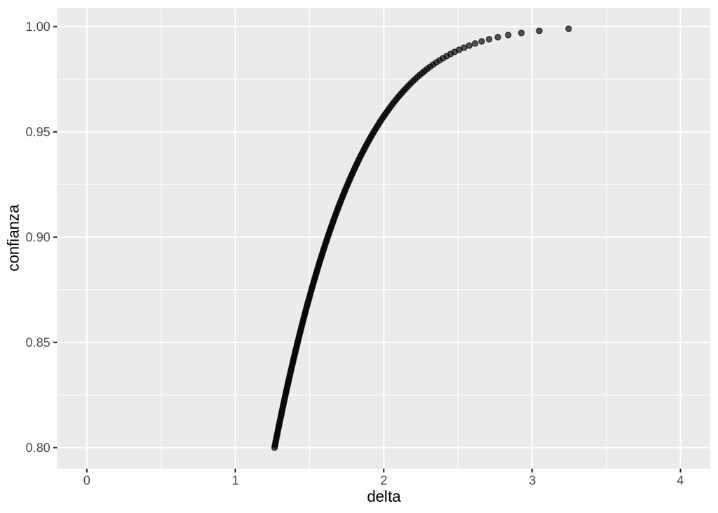

```r
ggplot(datos_delta_vs_alpha) +
  geom_point(mapping = aes(x = delta, y= confianza), alpha = 0.65 ) +
  scale_x_continuous(limits = c(0,4))
```

Si nos interesara algun valor particular de confianza o delta podemos filtrar para conocer los valores excatos de los parámetros involucrados

```r
datos_delta_vs_alpha %>% filter(confianza %in% c(0.90,0.95,0.99))
```

```
##   alpha    delta confianza
## 1  0.01 2.540855      0.99
## 2  0.05 1.933352      0.95
## 3  0.10 1.622520      0.90
```

### Post Estratificación

En algunos casos se querrá que las frecuencias de variables importantes en la muestra sean más representativas y por ello se ajustan los factores de expansión para qué tomen en cuenta las proporciones poblacionales de las variables categóricas de mayor interés.

Se conocen las frecuencias de cada categoría en la población, los factores de expansión se ajustan para coincidir con esas frecuencias.

La post-estratificación es un procedimiento similar a la estratificación, con la diferencia de que es realizada después de haber obtenido los resultados de las encuestas, es decir, una vez que ya contamos con los datos obtenidos de campo.

Consiste en la creación de nuevos grupos llamados post-estratos, se utiliza para corregir los efectos de la no respuesta o para afinar (ajustar) los factores de expansión.

Para calcular el factor de cada post-estrato se puede tomar la siguiente fórmula

$\text{factor post} = \frac{N_h}{n_m}$

notar que $n_m$ se refiere al número de elementos de la muestra que fueron efectivamente recabados de la labor de campo. $N_h$ es el número de elementos de la población en el estrato h

Por ejemplo, consideremos hacer post-estratificación de la variable sexo. El número de elementos por sexo en la población es

```r
personas_01 %>% group_by(SEXO) %>%  summarise(Freq = n())
```

```
## # A tibble: 2 x 2
##   SEXO   Freq
##   <chr> <int>
## 1 1     34025
## 2 3     35779
```

Tomar una muestra de 800

```r
N <- dim(personas_01)[1]

set.seed(123)
muestra_mas <- personas_01 %>%
              sample_n(800) %>%
              # crear la variable de factor de expasión
              mutate(factor_mas = N/800, fpc = 800/N)

#glimpse(muestra_mas)
```

Validar el factor de expansión

```r
muestra_mas %>% summarise(Total = sum(factor_mas))
```

```
## # A tibble: 1 x 1
##   Total
##   <dbl>
## 1 69804
```

Revisar el total para hombres y mujeres

```r
muestra_mas %>% group_by(SEXO) %>% summarise(Total = sum(factor_mas))
```

```
## # A tibble: 2 x 2
##   SEXO   Total
##   <chr>  <dbl>
## 1 1     33506.
## 2 3     36298.
```

Como vemos, los factores expanden correctamente el total de la población, pero no es así para la variable sexo.

¿Cuál es el factor de expansión de cada elemento?. ¿Cómo se ajustarían los factores si quisieramos que los subtotales (marginales) por sexo coincidieran con los de la población?

```r
Nh <- personas_01 %>% group_by(SEXO) %>%  summarise(Freq = n()) %>% select(Freq) %>% pull()
nh <- muestra_mas %>% group_by(SEXO) %>% summarise(nh = n()) %>% select(nh) %>% pull()

Nh/nh
```

```
## [1] 88.60677 86.00721
```

Estos serían los nuevos factores de la variable sexo para las categorías 1 y 3 respectivamente, mientras que el factor original era 87.255

¿Cómo hubieran quedado los factores si inicialmente se hubiera planteado estratificar por sexo?

Crear vector de estratos y tamaños de muestra por estrato

```r
n <- 800
tabla_auxiliar <- personas_01 %>% group_by(SEXO) %>%
    summarise(Nh = n()) %>%
    mutate(nh = round(n*(Nh/sum(Nh))),
           factorh = Nh/nh)
print(tabla_auxiliar)
```

```
## # A tibble: 2 x 4
##   SEXO     Nh    nh factorh
##   <chr> <int> <dbl>   <dbl>
## 1 1     34025   390    87.2
## 2 3     35779   410    87.3
```

Recapitulando, ¿qué diferencia hay entre estratificar y post-estratificar?.

La librería survey en R nos permite hacer post-estratificación con la función `postStratify`

Se debe definir el diseño

```r
disenio_mas <- svydesign( id =~1, data = muestra_mas, weights = ~factor_mas , fpc = ~fpc)
```

Se debe definir la tabla con los valores poblacionales

```r
totales_poblacion_sexo <- personas_01 %>% group_by(SEXO) %>% summarise(Freq = n())
```

La función generará un objeto con el diseño ajustado por la post-estratificación con los pesos correspondientes

```r
post_est_design <-
  postStratify(
    disenio_mas , # diseño
        strata = ~SEXO , #variable de estratificación
        population = totales_poblacion_sexo # Tabla con valores poblacionales para la variable de estratificación
    )
```

El elemento postStrata del objeto creado por la función `postStratify` contiene los pesos originales y los pesos ajustados

```r
x_post <- post_est_design$postStrata[[1]]
oldweights_post <- attributes(x_post)$oldweights %>% as.vector()
weights_post <- attributes(x_post)$weights %>% as.vector()
```

```r
table(weights_post,oldweights_post)
```

```
##                   oldweights_post
## weights_post       87.255
##   86.0072115384615    416
##   88.6067708333333    384
```

Se pueden hacer estimaciones usando el nuevo objeto del diseño con los factores ajustados

```r
svyby(~edad_numerica, ~SEXO, post_est_design, svymean)
```

```
##   SEXO edad_numerica       se
## 1    1      27.46354 1.050575
## 3    3      28.11779 0.967411
```

Agregarle los pesos de posst-estratificación a la muestra

```r
# glimpse(muestra_mas)
muestra_mas2 <- muestra_mas %>%
                mutate(factor_post = weights_post)
```

```r
muestra_mas2 %>% group_by(SEXO,factor_mas,factor_post) %>% summarise(n = n())
```

```
## # A tibble: 2 x 4
## # Groups:   SEXO, factor_mas [2]
##   SEXO  factor_mas factor_post     n
##   <chr>      <dbl>       <dbl> <int>
## 1 1           87.3        88.6   384
## 2 3           87.3        86.0   416
```

**Raking**

El ajuste anterior se puede ver como una tabla de contingencia donde cada celda representa un post-estrato y para hacer el ajuste es necesario se en la muestra salgan seleccionados elementos que caigan en cada categoría.

Se han desarrollado algotitmos iterativos que ajustan los pesos sin necesidad de tener información de cada celda, se usan los totales marginales, donde se itera hasta la convergencia de los totales objetivo de las variables marginales.

Revisar el algoritmo raking para conocer mayor detalle.

Realizaremos un ejemplo con la versión del algoritmo implementada en el paquete survey

Definir tabla con los valores poblacionales

```r
totales_poblacion_sexo <- personas_01 %>% group_by(SEXO) %>% summarise(Freq = n())
totales_poblacion_alfabet <- personas_01 %>% group_by(ALFABET) %>% summarise(Freq = n())
```

```r
rake_design <-
  rake(
    disenio_mas ,
        sample = list(~SEXO, ~ALFABET) ,
        population = list(totales_poblacion_sexo, totales_poblacion_alfabet)
    )
```

Totales poblacionales

```r
personas_01 %>% group_by(ALFABET) %>% summarise( total = n())
```

```
## # A tibble: 4 x 2
##   ALFABET total
##   <chr>   <int>
## 1 ""       7676
## 2 "1"     57421
## 3 "3"      4158
## 4 "9"       549
```

```r
personas_01 %>% group_by(ALFABET) %>% summarise( total = n())
```

```
## # A tibble: 4 x 2
##   ALFABET total
##   <chr>   <int>
## 1 ""       7676
## 2 "1"     57421
## 3 "3"      4158
## 4 "9"       549
```

Estimar totales

Sin post estratificación

```r
svytotal(~SEXO+ALFABET,disenio_mas)
```

```
##             total      SE
## SEXO1    33505.92 1226.67
## SEXO3    36298.08 1226.67
## ALFABET   6631.38  719.93
## ALFABET1 57937.32  922.29
## ALFABET3  4624.51  610.68
## ALFABET9   610.78  228.66
```

vemos como se ajustaron los pesos

```r
x_rake <- rake_design$postStrata[[1]][[1]]
#oldweights_rake <- attributes(x_rake)$oldweights %>% as.vector()
weights_rake <- attributes(x_rake)$weights %>% as.vector()
```

```r
data.frame(weights_rake) %>% group_by(weights_rake) %>% summarise(n = n())
```

```
## # A tibble: 8 x 2
##   weights_rake     n
##          <dbl> <int>
## 1         77.3    25
## 2         77.5     4
## 3         79.5    28
## 4         79.7     3
## 5         85.3   351
## 6         87.8   313
## 7         99.5    36
## 8        102.     40
```

Agregarle los pesos de la función rake rake a la muestra

```r
# glimpse(muestra_mas)
muestra_mas3 <- muestra_mas %>%
                mutate(factor_rake = weights_rake)
```

```r
muestra_mas3 %>% group_by(SEXO,ALFABET,factor_mas,factor_rake) %>% summarise(n = n())
```

```
## # A tibble: 8 x 5
## # Groups:   SEXO, ALFABET, factor_mas [8]
##   SEXO  ALFABET factor_mas factor_rake     n
##   <chr> <chr>        <dbl>       <dbl> <int>
## 1 1     ""            87.3       102.     40
## 2 1     "1"           87.3        87.8   313
## 3 1     "3"           87.3        79.5    28
## 4 1     "9"           87.3        79.7     3
## 5 3     ""            87.3        99.5    36
## 6 3     "1"           87.3        85.3   351
## 7 3     "3"           87.3        77.3    25
## 8 3     "9"           87.3        77.5     4
```

**inconvenientes de la post-estratificación**

- En casos muy particulares se pueden tener pesos muy fuertes